## Inequality in Sport: Money Brings Success

### [İlhan Güner](https://gunerilhan.github.io) and [Mehdi Hamidi Sahneh](https://www.kent.ac.uk/economics/staff/profiles/mehdi-hamidi-sahneh.html)

In this study we first show that over the last two decades

- level of competitiveness in the top European football (leagues) have decreased,
- concurrently, inequality in the squad values of the clubs have increased.

These results suggest that economic factors contribute a fair amount toward teams performance, in the sense that richer clubs, through investing in their squads, have a higher chance of success. In other words, the rich clubs can buy success. However, it is also resonable to think that teams performance affect their economic situation. It is the classic chicken-and-egg problem.

To investigate the causal impact of economic factors on teams’ performance, we conduct a regression discontinuity design analysis. We examine the effects of participation in UEFA Champions League (UCL), a prestigious club competition with substantial financial benefits, on the subsequent performance of the teams. We find that participation in UCL

- improves the probability of winning a game by about 8 percentage points,
- and improves the within game goal difference by about 0.3 goals, on average.

Football is the most popular sport in the world and the success or failure of teams heavily impacts the leisure of people around the globe. According to FIFA, 3.5 billion people watched the record-breaking 2018 World Cup and the UEFA Champions League Final in 2018/19 attracted about 380 million viewers worldwide. The European football market is also economically important. The overall size of the European market continues to increase in revenue, reaching $28.4 billion for 2017/18 (Deloitte (2019)). The “big five” leagues (i.e., English Premier League, Spainish La Liga, Italian Serie A, German Bundesliga and French Ligue 1) generated a record $15.6 billion in revenues for 2017/18. The socio-economic importance attached to football is predicated on the assumption that there will be a certain level of competitiveness.

The level of competitiveness in sport is closely connected to the concept of inequality. In a perfectly competitive match, each team have an equal chance of winning or losing. Investigating the change in the distribution of these probabilities then provides a picture of the level of competitiveness in different leagues and across time. Yet despite researchers’ best efforts, little is known about how to obtain ex-ante probability of different events in sport.

In this paper, we use the *bookmaker’s odds* to measure the ex-ante probability of different events. Analogues to stock prices, betting odds aggregate all the public and private information about the probability of different events as expressed by the amounts of money wagered for and against it. From the betting odds data downloaded from [Football-Data.co.uk](http://www.football-data.co.uk/englandm.php), for each game $i$ we extract the probability of the *Home* team winning ($P_i^H$), the probability of the team winning ($P_i^A$), and a *Draw* ($P_i^A$). As shown in the following graphs, betting markets do an excellent job of predicting the outcome of the games. If the market thinks that home team has, say 30% chance of winning, about 30% percent of games with similar ex-ante probability are won by the home teams. Therefore, betting data provide accurate and rich data on the probabilities of each team winning.

### Predictive performance of the betting markets

[figure not shown]

We relate the competitiveness to the change in distribution of probability margins, defined as the difference between the probability of the Home team beating the Away team ($P_i=P_i^H-P_i^A$). Absolute value of $P_i$ vary between 0 and $1$, with zero corresponding to both teams have equal chance of winning (i.e., close game), while $P_i$ close to 1 imply that one team has all the chance to win game $i$, while the other team has no chance of winning (one-sided game).

We then investigate the distribution of the probability margins to investigate the level of competitiveness in different leagues and over time. As we look at the distribution of the absolute value of $P_i$s, we see that over the period 2000-2019, the share of the close games (i.e., $|P_i|<1/3$) is decreasing and the share of the one-sided games (i.e., $|P_i|\geq2/3$) is increasing, as seen in the following graph. For example, in La Liga there was no one-sided game in the 2000-2001 season, but 15% of the games were one-sided in 2016-2017 season.

### Share of close and one-sided games over time

[interactive chart not shown]

We also provide a competitiveness index which looks at the whole distribution of the $P_i$. Our index, which is based on the *Atkinson inequality measure* (Atkinson (1970)), confirms our finding that the level of competitiveness has been decreasing for the big five leagues.

### Level of competitiveness in football leagues over time

[interactive chart not shown]

Furthermore, using data from https://www.transfermarkt.com, we provide evidence that inequality of squad market values among football clubs have been rising.

### Inequality in squad values in football leagues over time

[interactive chart not shown]

Although it is expected that economic factors affect the level of competitiveness, the identification strategy that aims at isolating such causal effects needs to address the potential endogeneity. There are two sources of endogeneity in our context: First, the omitted variable bias, e.g., the better management may improve team performance and is more likely to be positively correlated with higher revenues, implying a positive bias in the estimated effects. Second, the association between income inequality and the level of competitiveness could be due to reverse causality, i.e., it may be the case that decreasing level of competitiveness has caused the income inequality to increase.

Our empirical strategy overcomes these problems using a regression discontinuity design which exploits a jump in performance around the threshold to participate in the UEFA Champions League (UCL). More precisely, at the end of each season, 3-4 teams (from each top-five league) that obtain the most number of points are eligible for the next season’s UCL. However, eligibility does not necessarily imply participation in the UCL. That is because 1-2 of the eligible teams should go through play-off rounds, with some chance of elimination. This setup naturally leads to a fuzzy regression discontinuity design, using the discontinuity in the UCL participation as an instrumental variable for distance from the country-specific cutoff points. Participation in the UCL comes with substantial financial incentives. This include both direct income (e.g., matchday revenues, TV revenues), as well as indirect income (e.g., advertisements, leverage in the transfer market). Our identification methodology captures the combined effect of participation in the UCL.

We find that the probability to participate in the UCL shows a significant discontinuity at the country-specific cutoff point, supporting the validity of our research design. In addition, standard RD validity checks provide no evidence for violations of local random assignment, thus reinforcing our identification strategy. Our RD estimates show that UCL participation has a positive and significant effect on the subsequent performance of the teams. Precisely, our RD estimates shows that participation in the UCL increases the probability of winning a game next season by about 8 percentage points, and the within game goal difference by about 0.3 goals.

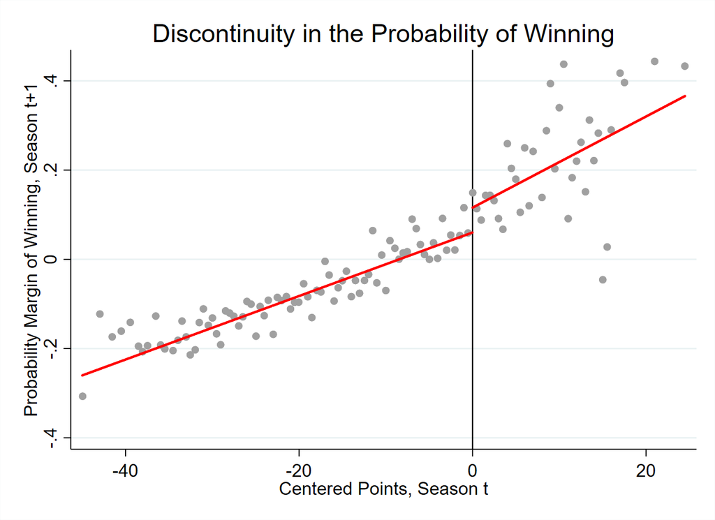

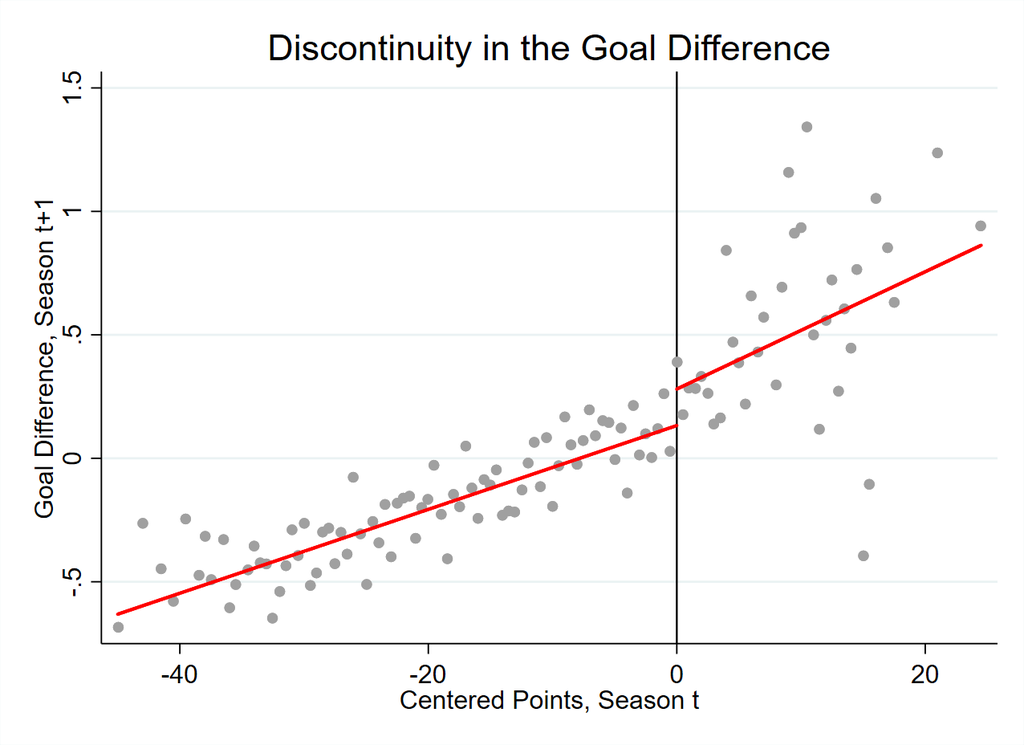

### References

Atkinson, A. B. et al., 1970. On the measurement of inequality. Journal of economic theory, 2(3):244–263.

Deloitte, The Annual Review of Football Finance, 2019

Michie, J. and Oughton, C., 2004. Competitive balance in football: Trends and effects. The sportsnexus London.

Borooah, V. K. and Mangan, J., 2012. Measuring competitive balance in sports using generalized entropy with an application to english premier league football. Applied Economics, 44(9):1093–1102.